# code-seminar-analysis

## Overiew

This worksheet contains code to analyze responses during a University of Utah Internal Medicine Residency Seminar to teach interns how to run code blues and rapid responses.

The course materials are hosted at: https://reblocke.github.io/talks/2024-Code-RR

### Descriptive Statistics

```
  pre_con_code    pre_con_rap    pre_nerv_code     pre_nerv_rap
 Min.   :2.000   Min.   :4.000   Min.   : 3.000   Min.   :4.000
 1st Qu.:3.250   1st Qu.:5.000   1st Qu.: 5.000   1st Qu.:5.000
 Median :5.000   Median :6.000   Median : 7.000   Median :5.000
 Mean   :4.944   Mean   :5.722   Mean   : 6.722   Mean   :5.833
 3rd Qu.:6.000   3rd Qu.:6.000   3rd Qu.: 8.000   3rd Qu.:7.000
 Max.   :9.000   Max.   :8.000   Max.   :10.000   Max.   :8.000
 post_con_code    post_con_rap   post_nerv_code  post_nerv_rap
 Min.   :4.000   Min.   :5.000   Min.   :2.000   Min.   :2.000
 1st Qu.:6.000   1st Qu.:6.250   1st Qu.:5.000   1st Qu.:3.250
 Median :7.000   Median :7.000   Median :6.000   Median :5.000
 Mean   :6.889   Mean   :7.167   Mean   :5.722   Mean   :4.833
 3rd Qu.:8.000   3rd Qu.:8.000   3rd Qu.:7.000   3rd Qu.:6.750
 Max.   :9.000   Max.   :9.000   Max.   :8.000   Max.   :7.000
    code_obs       rapids_obs     intern_lead    intern_sims
 Min.   :0.000   Min.   : 4.00   Min.   :0.00   Min.   :0.000
 1st Qu.:1.000   1st Qu.:10.00   1st Qu.:0.25   1st Qu.:0.000
 Median :2.500   Median :10.00   Median :2.00   Median :1.000
 Mean   :2.722   Mean   :14.22   Mean   :2.00   Mean   :1.111
 3rd Qu.:4.000   3rd Qu.:18.75   3rd Qu.:2.75   3rd Qu.:1.000
 Max.   :8.000   Max.   :35.00   Max.   :6.00   Max.   :5.000
    q_right       change_con_code change_con_rap  change_nerv_code
 Min.   :0.2857   Min.   :0.000   Min.   :0.000   Min.   :-5
 1st Qu.:0.4286   1st Qu.:1.000   1st Qu.:1.000   1st Qu.:-2
 Median :0.5714   Median :2.000   Median :1.000   Median :-1
 Mean   :0.5794   Mean   :1.944   Mean   :1.444   Mean   :-1
 3rd Qu.:0.7143   3rd Qu.:2.750   3rd Qu.:2.000   3rd Qu.: 0
 Max.   :0.8571   Max.   :4.000   Max.   :4.000   Max.   : 3
 change_nerv_rap
 Min.   :-3
 1st Qu.:-2
 Median :-1
 Mean   :-1
 3rd Qu.: 0
 Max.   : 2
```

#### Raw data

```r
library(tinytable)
tt(survey_responses)
```

| pre_con_code | pre_con_rap | pre_nerv_code | pre_nerv_rap | post_con_code | post_con_rap | post_nerv_code | post_nerv_rap | code_obs | rapids_obs | intern_lead | intern_sims | q_right | change_con_code | change_con_rap | change_nerv_code | change_nerv_rap |
| --- | --- | --- | --- | --- | --- | --- | --- | --- | --- | --- | --- | --- | --- | --- | --- | --- |
| 7 | 7 | 5 | 5 | 9 | 8 | 8 | 3 | 4 | 10 | 2 | 2 | 0.7142857 | 2 | 1 | 3 | -2 |
| 6 | 6 | 6 | 6 | 7 | 7 | 5 | 5 | 3 | 7 | 0 | 1 | 0.2857143 | 1 | 1 | -1 | -1 |
| 3 | 4 | 10 | 7 | 4 | 5 | 5 | 5 | 1 | 20 | 0 | 0 | 0.4285714 | 1 | 1 | -5 | -2 |
| 6 | 6 | 6 | 7 | 8 | 8 | 6 | 7 | 5 | 5 | 0 | 0 | 0.5714286 | 2 | 2 | 0 | 0 |
| 5 | 5 | 7 | 7 | 5 | 5 | 7 | 7 | 2 | 10 | 2 | 0 | 0.5714286 | 0 | 0 | 0 | 0 |
| 3 | 5 | 7 | 5 | 4 | 6 | 7 | 5 | 4 | 15 | 3 | 1 | 0.5714286 | 1 | 1 | 0 | 0 |
| 4 | 6 | 5 | 4 | 6 | 6 | 4 | 4 | 4 | 10 | 2 | 0 | 0.5714286 | 2 | 0 | -1 | 0 |
| 7 | 6 | 5 | 5 | 8 | 8 | 3 | 2 | 3 | 10 | 6 | 1 | 0.7142857 | 1 | 2 | -2 | -3 |
| 6 | 7 | 7 | 5 | 8 | 9 | 4 | 3 | 1 | 15 | 4 | 5 | 0.8571429 | 2 | 2 | -3 | -2 |
| 4 | 5 | 8 | 7 | 7 | 7 | 7 | 5 | 2 | 4 | 0 | 2 | 0.4285714 | 3 | 2 | -1 | -2 |
| 2 | 6 | 7 | 5 | 6 | 7 | 7 | 4 | 0 | 30 | 5 | 1 | 0.4285714 | 4 | 1 | 0 | -1 |
| 3 | 5 | 9 | 7 | 7 | 6 | 6 | 6 | 1 | 20 | 3 | 1 | 0.5714286 | 4 | 1 | -3 | -1 |
| 5 | 5 | 5 | 5 | 7 | 7 | 7 | 7 | 0 | 20 | 2 | 1 | 0.4285714 | 2 | 2 | 2 | 2 |
| 6 | 6 | 9 | 8 | 7 | 7 | 7 | 7 | 3 | 10 | 2 | 0 | 0.4285714 | 1 | 1 | -2 | -1 |
| 3 | 6 | 9 | 5 | 6 | 8 | 6 | 3 | 1 | 35 | 2 | 0 | 0.7142857 | 3 | 2 | -3 | -2 |
| 6 | 6 | 8 | 8 | 8 | 8 | 7 | 7 | 5 | 15 | 2 | 0 | 0.8571429 | 2 | 2 | -1 | -1 |
| 9 | 8 | 3 | 4 | 9 | 9 | 2 | 2 | 2 | 10 | 0 | 5 | 0.5714286 | 0 | 1 | -1 | -2 |
| 4 | 4 | 5 | 5 | 8 | 8 | 5 | 5 | 8 | 10 | 1 | 0 | 0.7142857 | 4 | 4 | 0 | 0 |

#### Summary Data

Pre

```r
library(modelsummary)
# Define custom functions for the 25th and 75th percentiles
q1 <- function(x) quantile(x, 0.25, na.rm = TRUE)
q3 <- function(x) quantile(x, 0.75, na.rm = TRUE)
n_non_missing <- function(x) sum(!is.na(x))

# Create the summary table with median, Q1, Q3, and N
datasummary((N = n_non_missing) +
            (Median = median) +
            (Q1 = q1) +
            (Q3 = q3) ~
              pre_con_code + pre_con_rap + pre_nerv_code + pre_nerv_rap,
            data = survey_responses)
```

|  | pre_con_code | pre_con_rap | pre_nerv_code | pre_nerv_rap |
| --- | --- | --- | --- | --- |
| N | 18.00 | 18.00 | 18.00 | 18.00 |
| Median | 5.00 | 6.00 | 7.00 | 5.00 |
| Q1 | 3.25 | 5.00 | 5.00 | 5.00 |
| Q3 | 6.00 | 6.00 | 8.00 | 7.00 |

Post

```r
datasummary((N = n_non_missing) +
            (Median = median) +
            (Q1 = q1) +
            (Q3 = q3) ~
              post_con_code + post_con_rap + post_nerv_code + post_nerv_rap,
            data = survey_responses)
```

|  | post_con_code | post_con_rap | post_nerv_code | post_nerv_rap |
| --- | --- | --- | --- | --- |
| N | 18.00 | 18.00 | 18.00 | 18.00 |
| Median | 7.00 | 7.00 | 6.00 | 5.00 |
| Q1 | 6.00 | 6.25 | 5.00 | 3.25 |
| Q3 | 8.00 | 8.00 | 7.00 | 6.75 |

Change in Scores

```r
datasummary((N = n_non_missing) +
            (Median = median) +
            (Q1 = q1) +
            (Q3 = q3) ~
              change_con_code + change_con_rap + change_nerv_code + change_nerv_rap,
            data = survey_responses)
```

|  | change_con_code | change_con_rap | change_nerv_code | change_nerv_rap |
| --- | --- | --- | --- | --- |
| N | 18.00 | 18.00 | 18.00 | 18.00 |
| Median | 2.00 | 1.00 | -1.00 | -1.00 |
| Q1 | 1.00 | 1.00 | -2.00 | -2.00 |
| Q3 | 2.75 | 2.00 | 0.00 | 0.00 |

Experience and performance

```r
datasummary((N = n_non_missing) +
            (Median = median) +
            (Q1 = q1) +
            (Q3 = q3) ~
              code_obs + rapids_obs + intern_lead + intern_sims + q_right,
            data = survey_responses)
```

|  | code_obs | rapids_obs | intern_lead | intern_sims | q_right |
| --- | --- | --- | --- | --- | --- |
| N | 18.00 | 18.00 | 18.00 | 18.00 | 18.00 |
| Median | 2.50 | 10.00 | 2.00 | 1.00 | 0.57 |
| Q1 | 1.00 | 10.00 | 0.25 | 0.00 | 0.43 |
| Q3 | 4.00 | 18.75 | 2.75 | 1.00 | 0.71 |

Easier, but doesn’t have percentiles

Unique

Missing Pct.

Mean

SD

Min

Median

Max

Histogram

pre_con_code

7

0

4.9

1.8

2.0

5.0

9.0

[figure not shown]

pre_con_rap

5

0

5.7

1.0

4.0

6.0

8.0

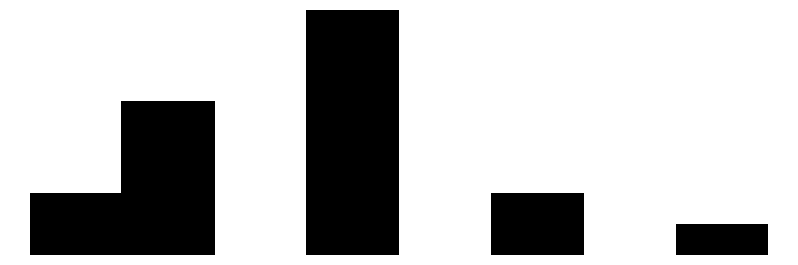

pre_nerv_code

7

0

6.7

1.9

3.0

7.0

10.0

[figure not shown]

pre_nerv_rap

5

0

5.8

1.3

4.0

5.0

8.0

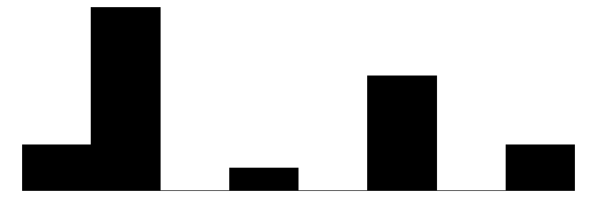

post_con_code

6

0

6.9

1.5

4.0

7.0

9.0

[figure not shown]

post_con_rap

5

0

7.2

1.2

5.0

7.0

9.0

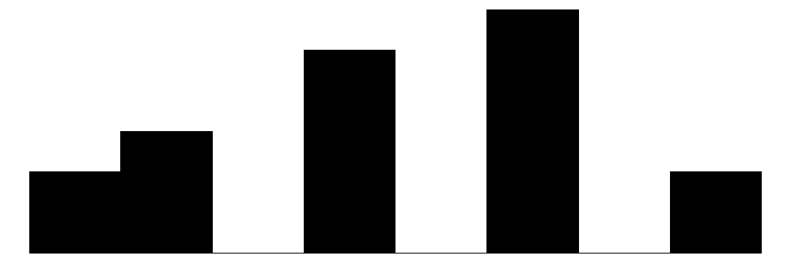

post_nerv_code

7

0

5.7

1.6

2.0

6.0

8.0

[figure not shown]

post_nerv_rap

6

0

4.8

1.8

2.0

5.0

7.0

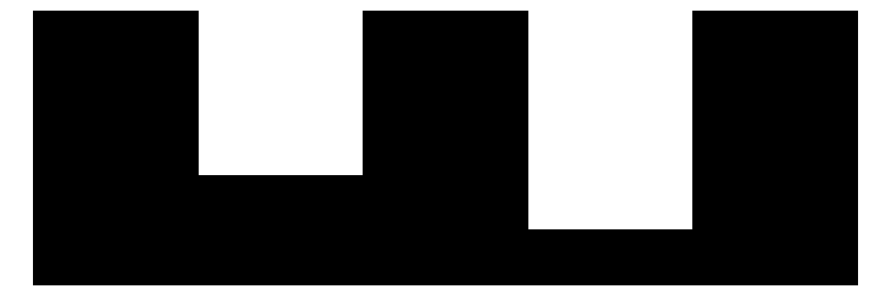

code_obs

7

0

2.7

2.1

0.0

2.5

8.0

[figure not shown]

rapids_obs

8

0

14.2

8.2

4.0

10.0

35.0

[figure not shown]

intern_lead

7

0

2.0

1.7

0.0

2.0

6.0

[figure not shown]

intern_sims

4

0

1.1

1.6

0.0

1.0

5.0

[figure not shown]

q_right

5

0

0.6

0.2

0.3

0.6

0.9

[5 more figures not shown]

```r
datasummary_skim(survey_responses)
```

Interesting!

### Univariate Visual Inspection

(I didn’t update these since they are superceded by the datasummary_skim call above)

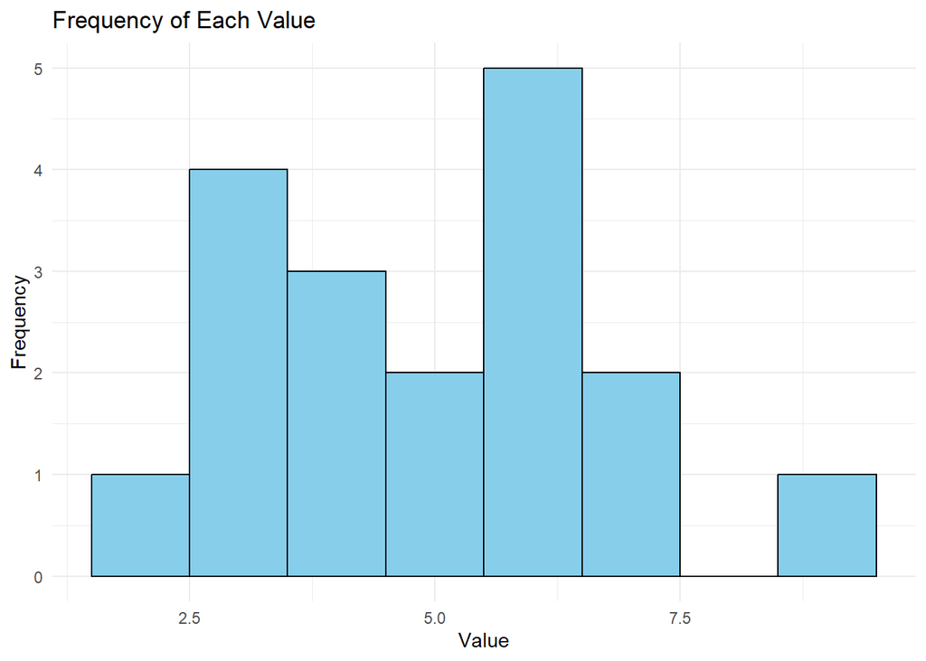

```r
library(ggplot2)

ggplot(survey_responses, aes(x = pre_con_code)) +
     geom_histogram(binwidth = 1, fill = "skyblue", color = "black") +
     labs(title = "Frequency of Each Value",
          x = "Value",
          y = "Frequency") +
     theme_minimal()
```

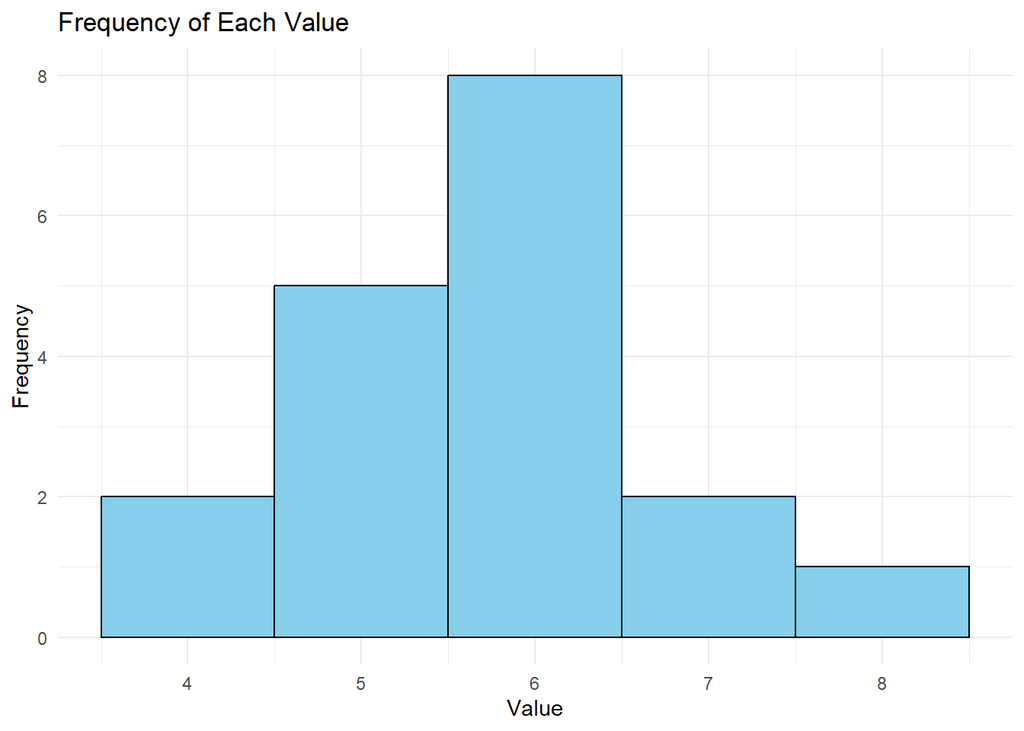

```r
ggplot(survey_responses, aes(x = pre_con_rap)) +
     geom_histogram(binwidth = 1, fill = "skyblue", color = "black") +
     labs(title = "Frequency of Each Value",
          x = "Value",
          y = "Frequency") +
     theme_minimal()
```

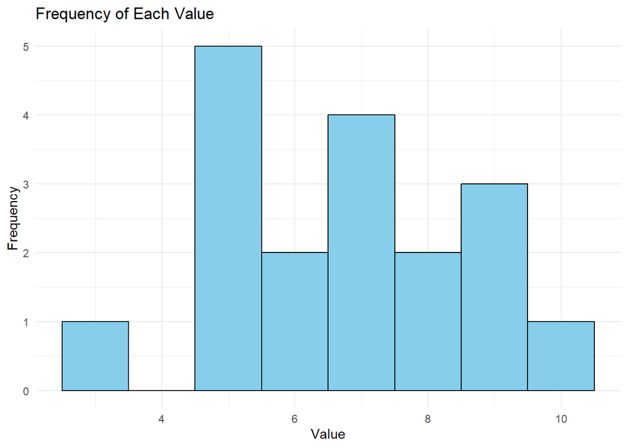

```r
ggplot(survey_responses, aes(x = pre_nerv_code)) +
     geom_histogram(binwidth = 1, fill = "skyblue", color = "black") +
     labs(title = "Frequency of Each Value",
          x = "Value",
          y = "Frequency") +
     theme_minimal()
```

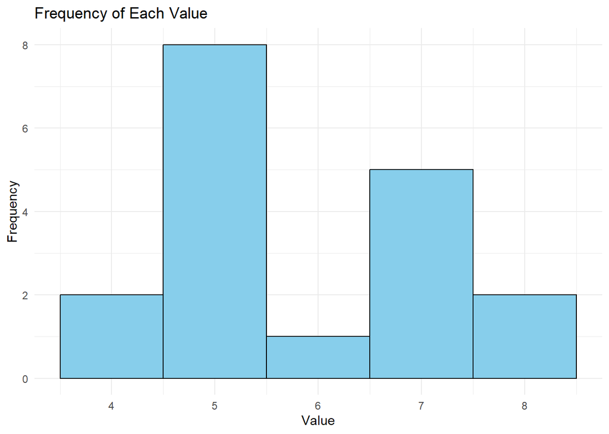

```r
ggplot(survey_responses, aes(x = pre_nerv_rap)) +
     geom_histogram(binwidth = 1, fill = "skyblue", color = "black") +
     labs(title = "Frequency of Each Value",
          x = "Value",
          y = "Frequency") +
     theme_minimal()
```

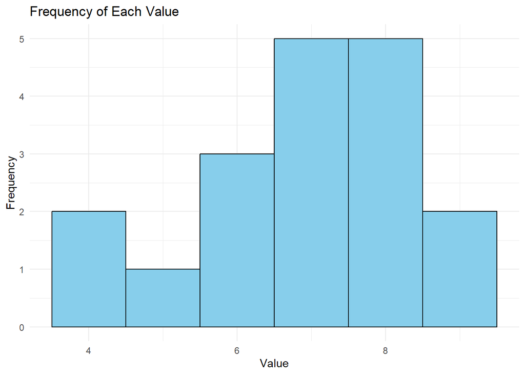

```r
ggplot(survey_responses, aes(x = post_con_code)) +
     geom_histogram(binwidth = 1, fill = "skyblue", color = "black") +
     labs(title = "Frequency of Each Value",
          x = "Value",
          y = "Frequency") +
     theme_minimal()
```

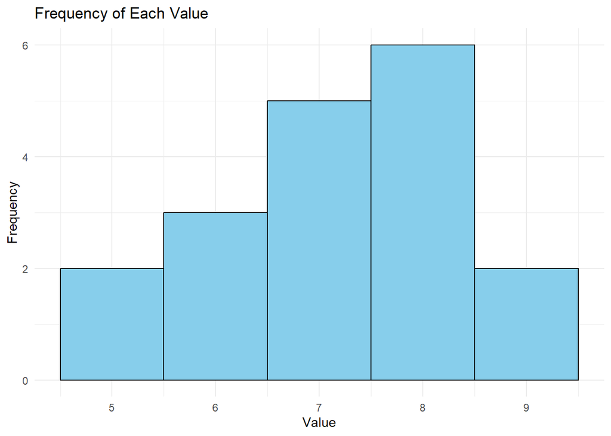

```r
ggplot(survey_responses, aes(x = post_con_rap)) +
     geom_histogram(binwidth = 1, fill = "skyblue", color = "black") +
     labs(title = "Frequency of Each Value",
          x = "Value",
          y = "Frequency") +
     theme_minimal()
```

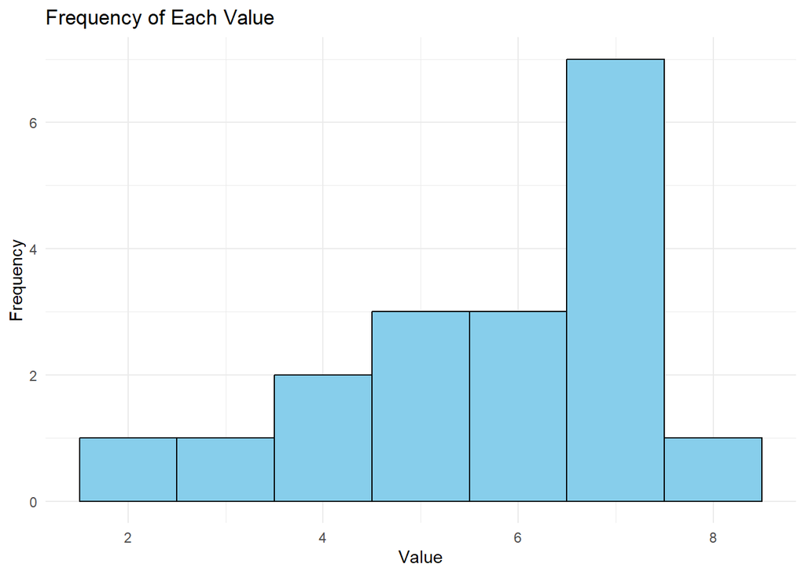

```r
ggplot(survey_responses, aes(x = post_nerv_code)) +
     geom_histogram(binwidth = 1, fill = "skyblue", color = "black") +
     labs(title = "Frequency of Each Value",
          x = "Value",
          y = "Frequency") +
     theme_minimal()
```

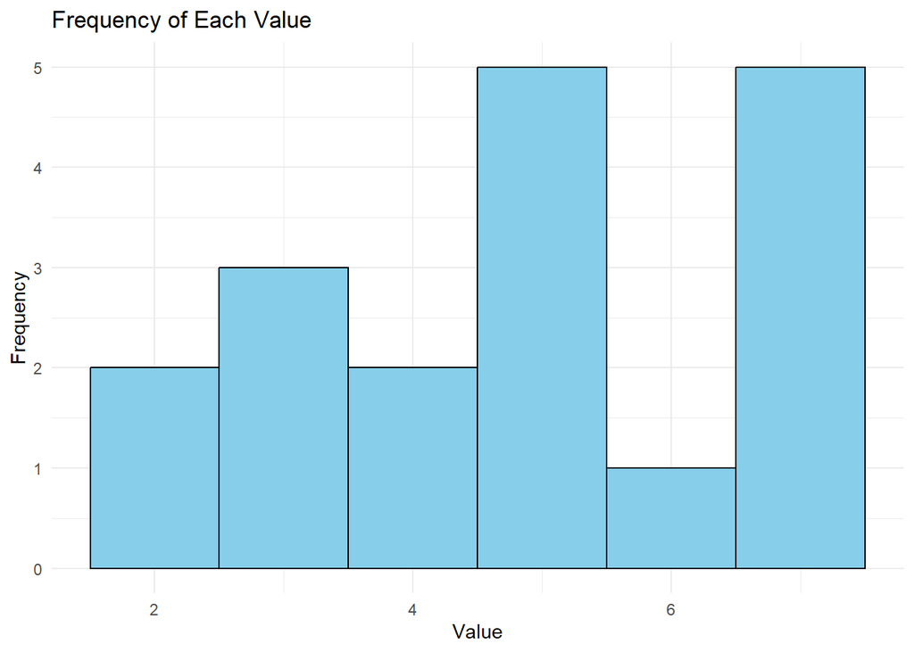

```r
ggplot(survey_responses, aes(x = post_nerv_rap)) +
     geom_histogram(binwidth = 1, fill = "skyblue", color = "black") +
     labs(title = "Frequency of Each Value",
          x = "Value",
          y = "Frequency") +
     theme_minimal()
```

### Correlations

```r
datasummary_correlation(survey_responses)
```

|  | pre_con_code | pre_con_rap | pre_nerv_code | pre_nerv_rap | post_con_code | post_con_rap | post_nerv_code | post_nerv_rap | code_obs | rapids_obs | intern_lead | intern_sims | q_right | change_con_code | change_con_rap | change_nerv_code | change_nerv_rap |
| --- | --- | --- | --- | --- | --- | --- | --- | --- | --- | --- | --- | --- | --- | --- | --- | --- | --- |
| pre_con_code | 1 | . | . | . | . | . | . | . | . | . | . | . | . | . | . | . | . |
| pre_con_rap | .69 | 1 | . | . | . | . | . | . | . | . | . | . | . | . | . | . | . |
| pre_nerv_code | -.59 | -.44 | 1 | . | . | . | . | . | . | . | . | . | . | . | . | . | . |
| pre_nerv_rap | -.08 | -.35 | .68 | 1 | . | . | . | . | . | . | . | . | . | . | . | . | . |
| post_con_code | .73 | .60 | -.54 | -.13 | 1 | . | . | . | . | . | . | . | . | . | . | . | . |
| post_con_rap | .59 | .67 | -.45 | -.32 | .83 | 1 | . | . | . | . | . | . | . | . | . | . | . |
| post_nerv_code | -.40 | -.33 | .43 | .48 | -.25 | -.33 | 1 | . | . | . | . | . | . | . | . | . | . |
| post_nerv_rap | -.22 | -.52 | .38 | .74 | -.25 | -.46 | .60 | 1 | . | . | . | . | . | . | . | . | . |
| code_obs | .21 | -.12 | -.31 | .05 | .30 | .21 | -.02 | .13 | 1 | . | . | . | . | . | . | . | . |
| rapids_obs | -.58 | -.09 | .41 | -.18 | -.37 | -.08 | .17 | -.15 | -.55 | 1 | . | . | . | . | . | . | . |
| intern_lead | -.15 | .13 | .00 | -.26 | -.02 | .08 | -.02 | -.31 | -.25 | .38 | 1 | . | . | . | . | . | . |
| intern_sims | .49 | .65 | -.39 | -.43 | .46 | .55 | -.45 | -.57 | -.30 | -.13 | .06 | 1 | . | . | . | . | . |
| q_right | .23 | .27 | -.11 | -.16 | .40 | .52 | -.15 | -.30 | .34 | .08 | .36 | .20 | 1 | . | . | . | . |
| change_con_code | -.59 | -.29 | .22 | -.04 | .12 | .12 | .28 | .02 | .04 | .40 | .19 | -.18 | .13 | 1 | . | . | . |
| change_con_rap | .02 | -.24 | -.09 | -.03 | .42 | .57 | -.07 | -.02 | .41 | .00 | -.04 | .00 | .38 | .48 | 1 | . | . |
| change_nerv_code | .24 | .15 | -.62 | -.27 | .32 | .16 | .44 | .14 | .29 | -.27 | -.02 | .00 | -.03 | .02 | .03 | 1 | . |
| change_nerv_rap | -.24 | -.39 | -.19 | .00 | -.23 | -.33 | .36 | .68 | .14 | -.02 | -.17 | -.38 | -.27 | .08 | .00 | .50 | 1 |

lots of interesting stuff in there.

### Visualize Bivariate Correlations of Interest

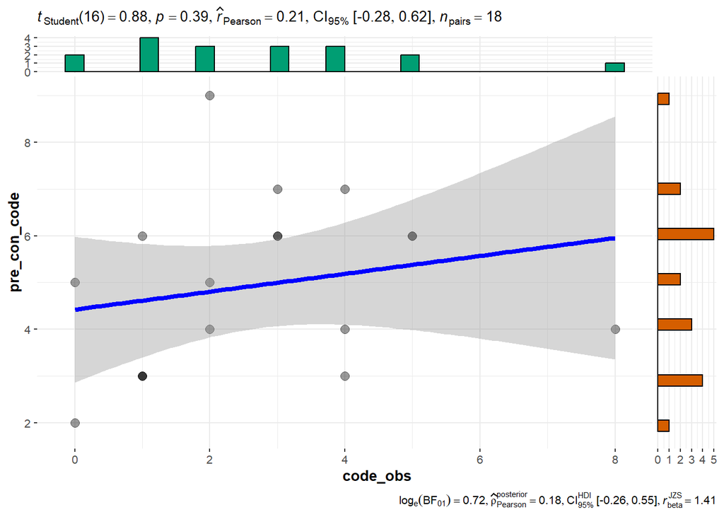

```r
ggstatsplot::ggscatterstats(data = survey_responses, x = code_obs, y = pre_con_code)
```

not much relationship between observations and confidence

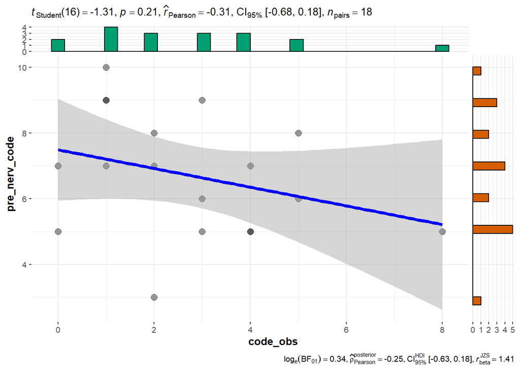

```r
ggstatsplot::ggscatterstats(data = survey_responses, x = code_obs, y = pre_nerv_code)
```

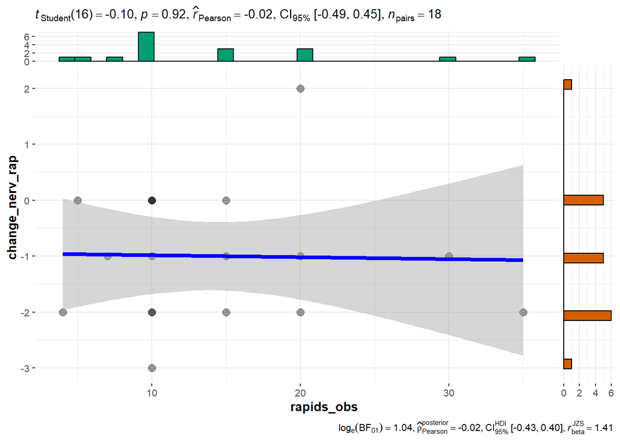

```r
ggstatsplot::ggscatterstats(data = survey_responses, x = rapids_obs, y = change_nerv_rap)
```

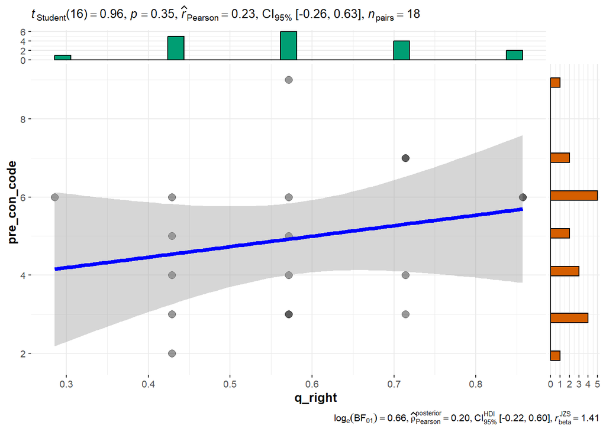

```r
ggstatsplot::ggscatterstats(data = survey_responses, x = q_right, y = pre_con_code)
```

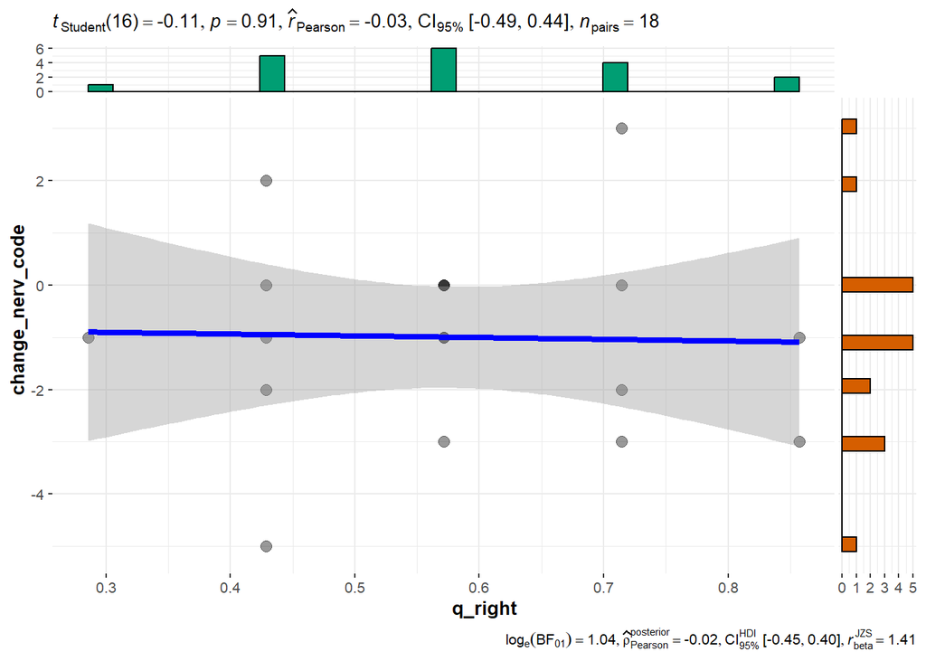

```r
ggstatsplot::ggscatterstats(data = survey_responses, x = q_right, y = change_nerv_code)
```

(Feel free to add more that seem interesting)

### Inferential Statistics

Now for some stats, just looking at the confidence and nervousness changes pre + post intervention with a paired t-test:

Pre + Post Confidence for Codes

```r
t.test(survey_responses$pre_con_code, survey_responses$post_con_code, paired = TRUE)
```

```
    Paired t-test

data:  survey_responses$pre_con_code and survey_responses$post_con_code
t = -6.5527, df = 17, p-value = 4.925e-06
alternative hypothesis: true mean difference is not equal to 0
95 percent confidence interval:
 -2.570508 -1.318381
sample estimates:
mean difference
      -1.944444
```

(You’ll notice that the paired t-test is the same as the 1 sample t-test of change_*** - because that is essentially what a paired t-test asks… is the difference not 0?)

Pre + Post Confidence for Rapids

```r
t.test(survey_responses$pre_con_rap, survey_responses$post_con_rap, paired = TRUE)
```

```
    Paired t-test

data:  survey_responses$pre_con_rap and survey_responses$post_con_rap
t = -6.6483, df = 17, p-value = 4.111e-06
alternative hypothesis: true mean difference is not equal to 0
95 percent confidence interval:
 -1.9028335 -0.9860554
sample estimates:
mean difference
      -1.444444
```

Pre + Post Nervousness for Codes

```r
t.test(survey_responses$pre_nerv_code, survey_responses$post_nerv_code, paired = TRUE)
```

```
    Paired t-test

data:  survey_responses$pre_nerv_code and survey_responses$post_nerv_code
t = 2.2583, df = 17, p-value = 0.03736
alternative hypothesis: true mean difference is not equal to 0
95 percent confidence interval:
 0.06575796 1.93424204
sample estimates:
mean difference
              1
```

Pre + Post Nervousness for Rapids

```r
t.test(survey_responses$pre_nerv_rap, survey_responses$post_nerv_rap, paired = TRUE)
```

```
    Paired t-test

data:  survey_responses$pre_nerv_rap and survey_responses$post_nerv_rap
t = 3.5707, df = 17, p-value = 0.002354
alternative hypothesis: true mean difference is not equal to 0
95 percent confidence interval:
 0.4091335 1.5908665
sample estimates:
mean difference
              1
```

Is there a way to have it output the t-test with a title? [ ] how do you mean?

Wanted to look at confidence and nervousness before intervention related to events attended and events lead (tried to include questions right in the second, tbh not sure how to interpret the results:

```r
library(modelsummary)
#Simple Linear Regression of Events observed + confidence
simple_con_model <- lm(pre_con_code ~ code_obs, data = survey_responses)
# summary(simple_con_model)
modelsummary(simple_con_model,
             output = "markdown",
             fmt = 2,
             statistic = 'conf.int',
             conf_level = 0.95) #better display
```

|  | (1) |
| --- | --- |
| (Intercept) | 4.42 |
|  | [2.87, 5.98] |
| code_obs | 0.19 |
|  | [-0.27, 0.65] |
| Num.Obs. | 18 |
| R2 | 0.046 |
| R2 Adj. | -0.013 |
| AIC | 77.0 |
| BIC | 79.6 |
| Log.Lik. | -35.481 |
| RMSE | 1.74 |

You’re correct - this says that confidence at Obs_code = 0 is 4.423 on average (that’s the intercept), and that for each code observed the confidence increases by 0.192 on average (but that it’s not significant - CI -0.27 to 0.65). Additionally, number of codes observed explains only 0.046 of the variation in confidence.

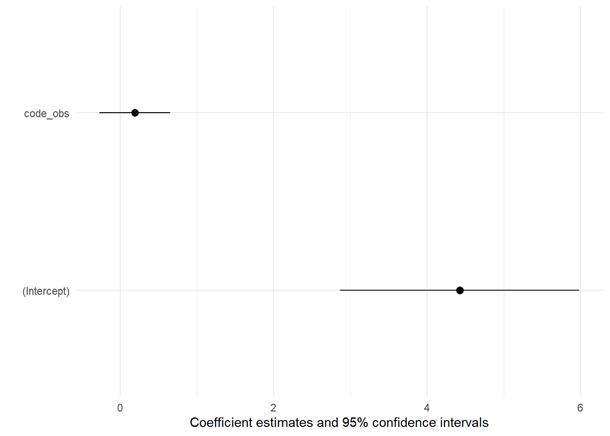

```r
modelplot(simple_con_model)
```

Now, with the limited sample size (n=18), we probably shouldn’t do more than 2 predictors in the model at any given time to avoid overfitting. But here’s an example of how I might do it:

Question: did number of codes observed change the post seminar nervousness after accounting for pre seminar nervousness?

```r
#Tried to add a second variable (questions right on quiz)
test_con_model <- glm(post_nerv_code ~ code_obs + pre_nerv_code, data = survey_responses)
# summary(test_con_model)
modelsummary(test_con_model,
             output = "markdown",
             fmt = 2,
             statistic = 'conf.int',
             conf_level = 0.95) #better display
```

|  | (1) |
| --- | --- |
| (Intercept) | 2.68 |
|  | [-0.67, 6.03] |
| code_obs | 0.10 |
|  | [-0.28, 0.48] |
| pre_nerv_code | 0.41 |
|  | [0.00, 0.83] |
| Num.Obs. | 18 |
| R2 | 0.202 |
| AIC | 71.8 |
| BIC | 75.3 |
| Log.Lik. | -31.882 |
| RMSE | 1.42 |

Answer: no, expected post-nerve increased by 0.1 per code observed, after accounting for the pre sem nervousness

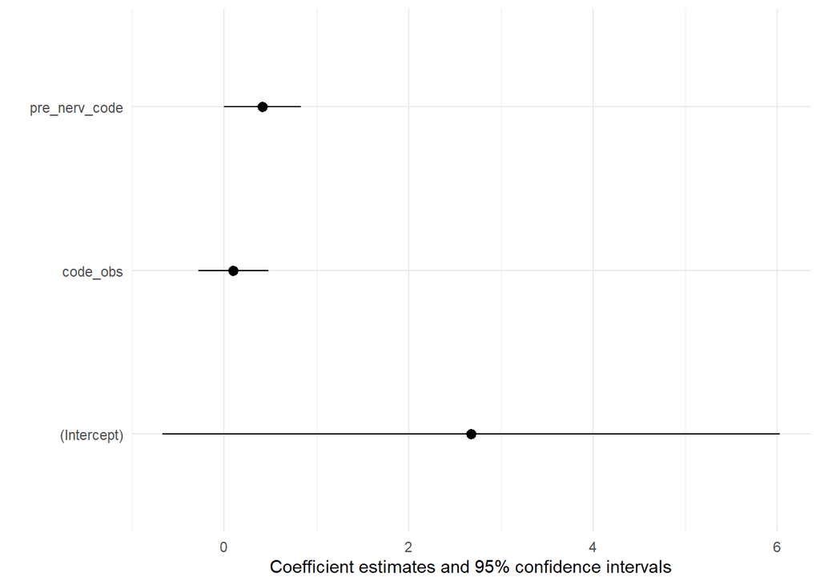

```r
modelplot(test_con_model)
```

some other cool regression-related packages to play around with:

check model assumptions

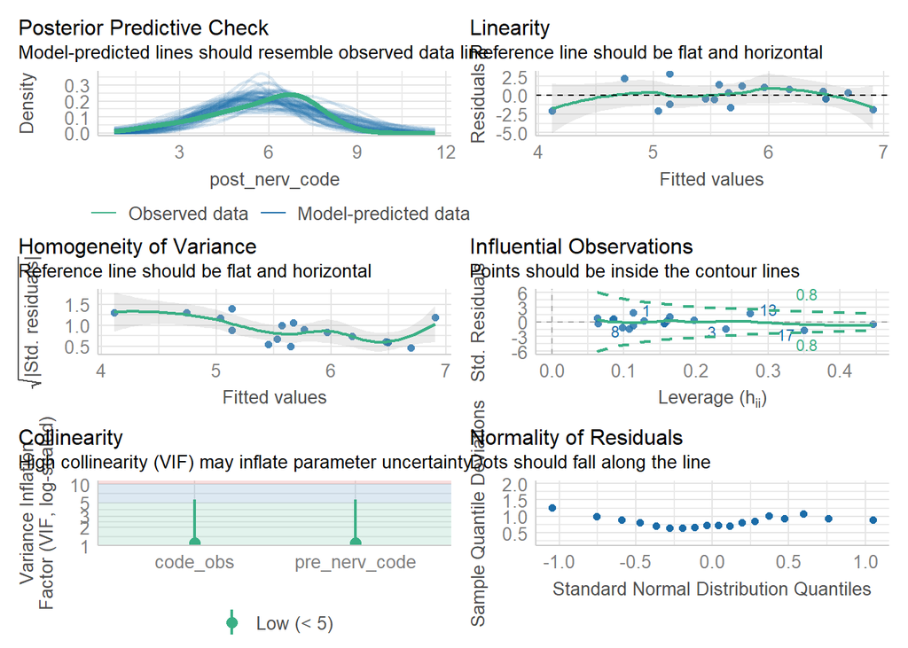

```r
library(performance)
check_model(test_con_model)
```